# Introduction to R - II

January 30, 2017

## for loop

```r
x = 36
for (x in seq(10)){
  cat(x, "\t") # x is the iterator
}
```

```
## 1    2   3   4   5   6   7   8   9   10
```

## for loop

```r
for (x in seq(10)){
  x = 3.9*x*(1-x)
  cat(x, "\t")
}
```

```
## 0    -7.8    -23.4   -46.8   -78     -117    -163.8  -218.4  -280.8  -351
```

## while loop

```r
a = 0
while(a<10){
  a = a+1 ## unlike C, a++, a+=1 won't work in R
  cat(a, "\t")
}
```

```
## 1    2   3   4   5   6   7   8   9   10
```

## apply, lapply, sapply, tapply

- You have some structured blob of data and you want to perform some operations by dimensions.
- e.g. calculate row-wise means or column-wise means

```r
m <- matrix(data=cbind(rnorm(30, 0), rnorm(30, 2), rnorm(30, 5)), nrow=30, ncol=3)
dim(m)
```

```
## [1] 30  3
```

```r
apply(m, 2, mean)
```

```
## [1] -0.165136  2.224684  4.979640
```

## apply (contd.)

- We can also calculate row-wise mean.

```r
apply(m, 1, mean)
```

```
##  [1] 1.709301 2.679496 2.405604 2.418085 2.367721 2.240985 1.736483
##  [8] 3.027484 1.458938 2.001021 2.263296 2.068013 1.962054 3.069366
## [15] 2.003599 2.497102 2.683324 2.769806 2.197533 2.318419 2.569120
## [22] 2.428683 3.082895 2.168518 1.618974 2.717272 2.295605 2.437214
## [29] 2.952410 2.243553
```

- Or, our own function: (how many negative numbers in each column?)

```r
apply(m, 2, function(x) length(x[x<0]))
```

```
## [1] 18  0  0
```

## lapply and sapply

- traversing over a set of data like a list or vector, and calling the specified function for each item.
- Usage: lapply(alist, afunction) - applies afunction to all the elements of a list or vector, returns a list of the results. Example:

```r
cap.state.name <- lapply(state.name, toupper)
head(cap.state.name, n = 3)
```

```
## [[1]]
## [1] "ALABAMA"
##
## [[2]]
## [1] "ALASKA"
##
## [[3]]
## [1] "ARIZONA"
```

## sapply

- Similar to lapply, but returns a simpler data structure: either a vector or array.

```r
sapply(1:3, function(x) x^2)
```

```
## [1] 1 4 9
```

- Remember: lapply is a list apply, sapply is simple lapply.
- Why do we care? apply, sapply, lapply are easier to read and **sometimes** faster than traditional for loops.

## Functions

- Functions are blocks of code that allows R to be modular and facilitate code reuse.
- An R programmer can define their own functions as follows:

```r
function_name <- function([arg1], [arg2], ...){
#function code body
}
```

- The function arguments are optional. Function arguments are the variables passed to the function, used by the function’s code to perform calculations. A function can take no arguments.
- A function can also return any R primitive or object using the return(object) statement.

## For loop vs apply

```r
N = 1e5
d <- as.data.frame(cbind(rnorm(N),runif(N)))

system.time(for (i in 1:N) {
    d$mean2[i] <- mean(c(d[i, 1], d[i, 2]))
})
```

```
##    user  system elapsed
##   25.25   22.33   48.15
```

```r
system.time(d$mean1 <- apply(d, 1, mean))
```

```
##    user  system elapsed
##    0.62    0.01    0.65
```

## Functions

- Examples

```r
# computes the mean of a vector of numbers
mean <- function(a_vector) {
s <- sum(a_vector)
x <- s/length(a_vector)
}
```

```r
# checks to see if a string s starts with letter x
startsWith <- function(x, s){
if(x == substr(s, 0, 1){
return(TRUE)
}
return(FALSE)
}
```

## Functions

- **Default arguments**
- Function arguments can be assigned default values as follows:

```r
sort_vector <- function(a_vector, ascending=TRUE){
# sorting algorithm
}
```

- When calling this function, the arguments given default values do not need to be specified. In this case, the defaults are used.
- Example:

```r
sort_vector(a_vector) # returns a_vector in ascending order
sort_vector(a_vector, FALSE) # returns a vector in descending order
```

## Functions

- Variable Scoping
- Variables that are bound to an R primitive or object outside a function are called global variables, and are accessible everywhere in an R program.
- Example:

```r
x <- 5
test <- function() {
cat(x + 5)
}
test();
```

```
## 10
```

## Functions

- Variables bound inside a function are only accessible within that function. These are called local variables.

```r
x <- 10
test <- function() {
x <- 5; cat(x + 20)
}
test() #prints 25
```

```
## 25
```

```r
cat(x + 20) #prints 30
```

```
## 30
```

**local variable assignment takes precedence inside the function over the global assignment**.

## Functions

- R functions have no side effects– they cannot change the value of global variables. Example:

```r
x <- 10
test <- function(z) {
z <- z + 10
cat(z)
}
test(x) #prints 20
```

```
## 20
```

```r
cat(x) #prints 10
```

```
## 10
```

- **Note that x is still bound to 10 outside of test()**.

## System time in R

```r
system.time(expr)
```

Return CPU times that “expr” used. A numeric vector of length 5 containing the user cpu, system cpu, elapsed, subproc1, subproc2 times. The subproc times are the user and system cpu time used by child processes (and so are usually zero).

## System time in R

```r
system.time(for(i in 1:5000) x<-mean(rnorm(1000)))
```

```
##    user  system elapsed
##    0.44    0.00    0.44
```

- The other way to get system time is using proc.time() function.
- `proc.time’ determines how much time (in seconds) the currently running R process already consumed. For example:

```r
now<-proc.time()
for(i in 1:5000) x<-mean(rnorm(1000))
proc.time()-now
```

```
##    user  system elapsed
##    0.42    0.00    0.44
```

## Vectorized arithmetic > loops

```r
x<-rnorm(1e7)
sum<-0
now<-proc.time()
for(i in 1:1e7){sum<-sum+x[i]}
meanx<-sum/1e7
proc.time()-now
```

```
##    user  system elapsed
##    0.48    0.00    0.53
```

- Use vectorized arithmetic instead of loops:

```r
system.time(mean(x))
```

```
##    user  system elapsed
##    0.03    0.00    0.03
```

## Finer control

```r
x = seq(1:1e4)
#install.packages("microbenchmark")
library(microbenchmark)
microbenchmark(sqrt(x),x^(0.5))
```

```
## Unit: microseconds
##     expr     min       lq      mean   median       uq     max neval
##  sqrt(x)  56.890  59.6560  73.49433  66.9640  82.7665 141.038   100
##  x^(0.5) 421.532 449.7785 493.11279 483.5565 518.1240 891.654   100
```

## Excercise 1

Here are two other ways to compute the square root of a vector. Which do you think will be fastest? Which will be slowest? Use microbenchmarking to test your answers.

```r
x ^ (1 / 2)
exp(log(x) / 2)
```

## More advanced topics in effcient R programming

## Time comparison: Ordinary Least Squares in Regression

- Compare execution times for the different methods of solving the Least Squares problem when the number of observations is large.
- Let us start by making up our own random data: \(n \times p\) design matrix \(X\) and an \(n \times 1\) response vector \(y\).
- Take \(n = 5 \times 10^5\).

```r
set.seed(123)
n <- 5e5; p <- 20
X <- matrix(rnorm(n * p, mean = 1 : p, sd = 10), nr = n, nc = p, byrow = TRUE)
y <- rowSums(X) + rnorm(n)
```

## OLS Solution

- The naive approach to solve the LS problem is to compute: \(\hat{\beta} = (X^T X)^{-1}X^T y\)

```r
system.time(bHat1 <- solve(t(X) %*% X) %*% t(X) %*% y)
```

```
##    user  system elapsed
##    0.46    0.03    0.56
```

- Not so naive: use `crossprod`.

```r
system.time(bHat2 <- solve(crossprod(X), crossprod(X, y)))
```

```
##    user  system elapsed
##    0.26    0.00    0.27
```

## Knowledge of Linear Algebra helps

- Inverting a matrix using Cholesky needs less time.
- A symmetric positive definite matrix can be factorized as: \[ A = L L^T \]

```r
p = 1000; A = array(rnorm(p*p), c(p,p))
A = crossprod(A)
ptm <- proc.time(); B = solve(A); proc.time()-ptm
```

```
##    user  system elapsed
##    0.89    0.00    0.89
```

```r
ptm <- proc.time(); B = chol2inv(A); proc.time()-ptm
```

```
##    user  system elapsed
##    0.25    0.00    0.33
```

## More advanced : Parallel

- If you have a task that has to be completed many times, but each repeat is independent, you should use parallel computing.
- For instance, if you are repreating a test, and in each case are using a new data-set, that is an easily parallelizable task.
- A good rule of thumb is that if you can wrap your task in an apply function or one of its variants, it’s a good option for parallelization.
- Parallel processing breaks up your task, splits it among **multiple** processors, and puts the components back together. https://hpc.uark.edu/

## Parallelism in R

- You can use R packages “doParallel” or “snow” and most parellelizing tasks are easy to implement.
- We will come back to Parallel computing when we talk about a more advanced nonparametric method: “Bootstrap”

## Permutation test

## Permutation test (Recap)

R function `combn` can be used to produce the indices corresponding to all \(\binom{6}{3}\) ways of choosing 3 elements out of 6 elements.

```r
(idx = combn(x = 6, m=3))
```

```
##      [,1] [,2] [,3] [,4] [,5] [,6] [,7] [,8] [,9] [,10] [,11] [,12] [,13]
## [1,]    1    1    1    1    1    1    1    1    1     1     2     2     2
## [2,]    2    2    2    2    3    3    3    4    4     5     3     3     3
## [3,]    3    4    5    6    4    5    6    5    6     6     4     5     6
##      [,14] [,15] [,16] [,17] [,18] [,19] [,20]
## [1,]     2     2     2     3     3     3     4
## [2,]     4     4     5     4     4     5     5
## [3,]     5     6     6     5     6     6     6
```

## Permutation test

```r
x=c(37,55,57)
y=c(23,31,70)
xy = c(x,y) # the combined data set

permut = NULL # the permuted data set (a 20*6 matrix)

for(i in 1:ncol(idx)){
  permut = rbind(permut, c(xy[idx[,i]], xy[-idx[,i]]))
}
permut.x = permut[, 1:3] # the permuted X matrix (20*3)
permut.y = permut[, 4:6] # the permuted Y matrix (20*3)
head(permut.x, n = 3)
```

```
##      [,1] [,2] [,3]
## [1,]   37   55   57
## [2,]   37   55   23
## [3,]   37   55   31
```

## Permutation test

```r
delta1 = apply(permut.x, 1, mean) - apply(permut.y, 1, mean)
delta1.obs = mean(x)-mean(y)
```

P-value for permutation of sample mean

```r
(pval1.upper = mean(delta1 >= delta1.obs)) #upper-tailed
```

```
## [1] 0.35
```

```r
(pval1.2sided = mean(abs(delta1) >= abs(delta1.obs))) #two-tailed
```

```
## [1] 0.7
```

## Histogram

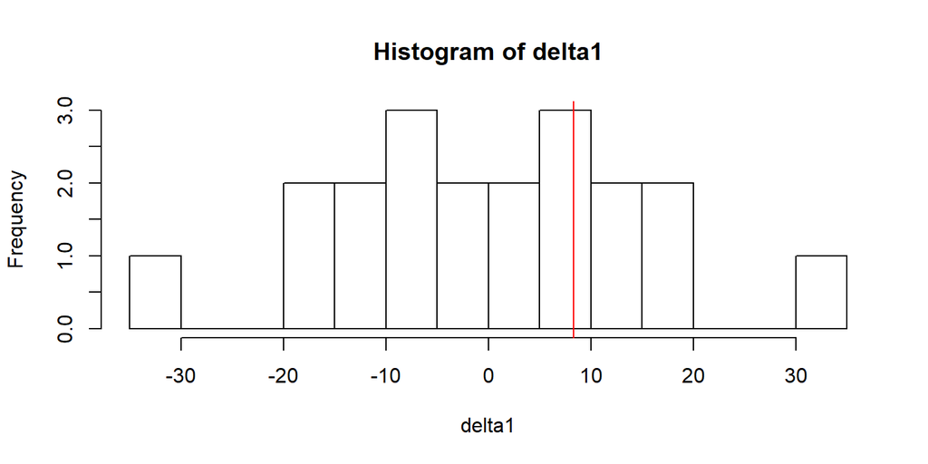

```r
hist(delta1,breaks=10);abline(v = delta1.obs,col="red")
```

## Permutation test code

```r
idx = combn(x = 6, m=3)
x=c(37,55,57)
y=c(23,31,70)
xy = c(x,y) # the combined data set
permut = NULL # the permuted data set (a 20*6 matrix)

for(i in 1:20){
  permut = rbind(permut, c(xy[idx[,i]], xy[-idx[,i]]))
}
permut.x = permut[, 1:3] # the permuted X matrix (20*3)
permut.y = permut[, 4:6] # the permuted Y matrix (20*3)

delta1 = apply(permut.x, 1, mean) - apply(permut.y, 1, mean)

delta1.obs = mean(x)-mean(y)

#pvalue for permutation of sample mean
(pval1.upper = mean(delta1 >= delta1.obs)) #upper-tailed
(pval1.2sided = mean(abs(delta1) >= abs(delta1.obs))) #two-tailed
hist(delta1,breaks=10);abline(v = delta1.obs,col="red")
```

## Exercise 2

Carter and Hubert (1985) give data for percentage variation in blood sugar over 1-hour periods for rabbits given two different dose levels of a drug, Is there evidence of a response difference between levels? Apply a Permutation test.

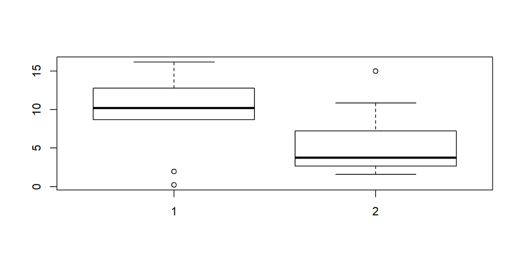

```r
dose.1 = c(0.21,16.20,10.10,8.67,11.13,1.96,10.19,15.87,12.81)
dose.2 = c(1.59,2.66,6.27,2.32,10.87,7.23,3.76,3.02,15.01)
boxplot(dose.1,dose.2)
```